# P&S-2022: Lab assignment 2

#### First, generate samples an sample means:

```
## Parameters of the standard normal approximation 0.04545455 0.02032789
```

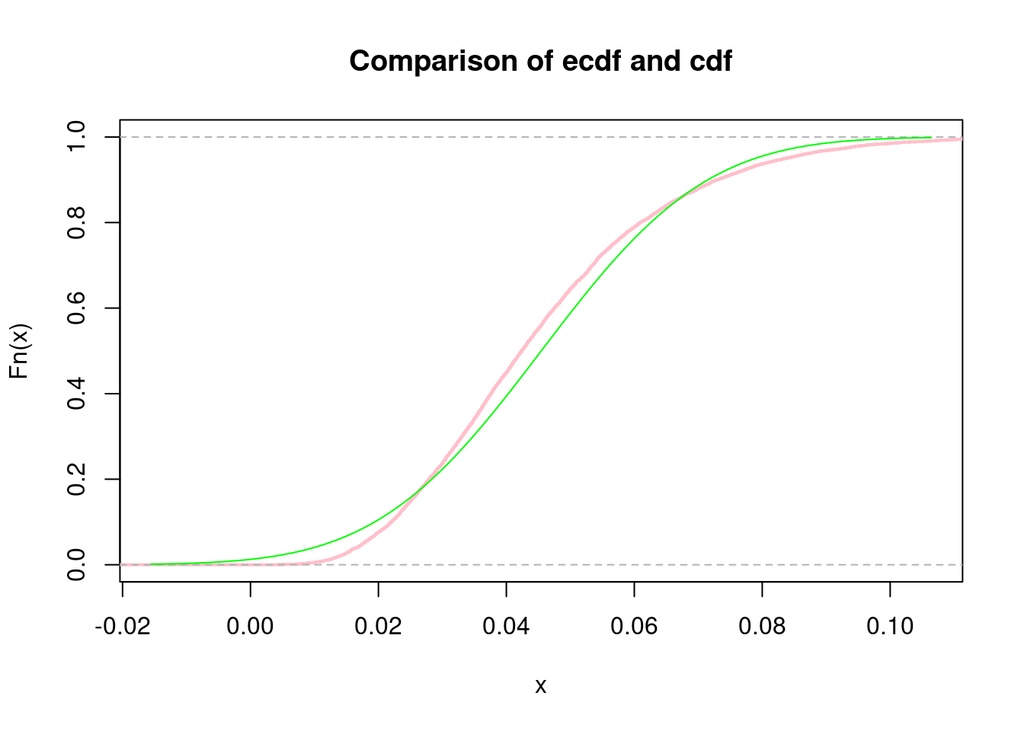

```
## Max difference 0.06154257
## We can see that with larger n (5,10,50) we have better approximation, max diference is less with each iteration,and graffics are almost overlap
## Parameters of the standard normal approximation 0.04545455 0.01437399
```

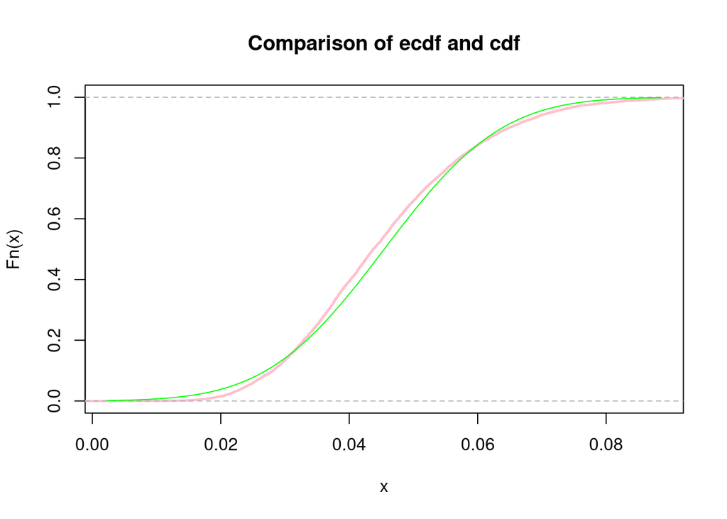

```
## Max difference 0.0468543
## We can see that with larger n (5,10,50) we have better approximation, max diference is less with each iteration,and graffics are almost overlap
## Parameters of the standard normal approximation 0.04545455 0.006428243
```

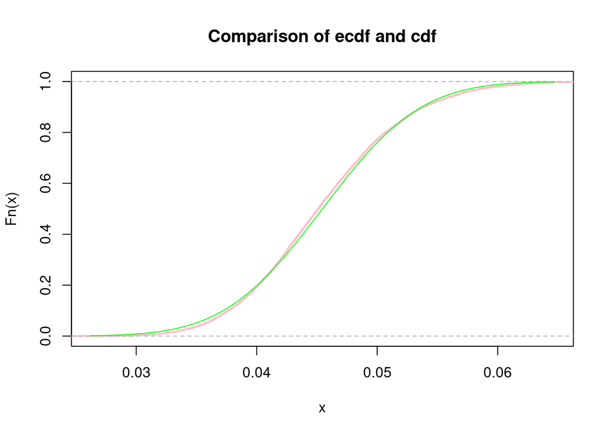

```
## Max difference 0.02348602
## We can see that with larger n (5,10,50) we have better approximation, max diference is less with each iteration,and graffics are almost overlap
```

```r
teamid <- 12
v <- teamid + 10
nu1 <- 1/v  #µ = 1/lambda
sigma_squared <- 1/(v^2)
K <- 10000

for (n in c(5,10,50)){

  sample_means <- colMeans(matrix(rexp(n*K, rate = v), nrow=n)) #generate vctor of samples
  Fs <- ecdf(sample_means) #emprirical ecdf from sample

  mu <- nu1       # expectation of sample mean is just µ
  sigma <- sqrt(sigma_squared) / sqrt(n)   # sd

  cat("Parameters of the standard normal approximation", mu, sigma, "\n")

  # Define xlims for the plot
  xlims <- c(mu - 3*sigma, mu + 3*sigma)

  Fs <- ecdf(sample_means)
  plot(Fs,
       xlim = xlims,
       col = "pink",
       lwd = 2,
       main = "Comparison of ecdf and cdf")
  curve(pnorm(x, mean = mu, sd = sigma), col = "green", add = TRUE)

  # take a grid of 200 points tj within 3σ of µ
  t_lims <- c(mu - 3 * sigma,mu + 3 * sigma )

  t_points <- seq(t_lims[1], t_lims[2], length.out = 200)
  #count values of Fs_t, Fz_t
  Fs_t <- Fs(t_points)
  Fz_t <- pnorm(t_points, mean = mu, sd = sigma)

  max_difference <- max(abs(Fs_t - Fz_t))

  cat("Max difference", max_difference, "\n")
  cat("We can see that with larger n (5,10,50) we have better approximation, max diference is less with each iteration,and graffics are almost overlap\n")
}
```

```r
#Part 2

#(a) express the event of interest in terms of the r.v. S := X1 + · · · + X100;

# We need to find P(S>60) ≥ 0.95
# Because if S is greater then 60 the 100's click happened after 1 minute. So , during one minute ≤ 99 clicks happened
# Each Xk has exponential distribution with rate v, and v = N * v1(rate for distribution when   N=1) = 22N


#(b) obtain the theoretical bounds on Central Limit Theorem

lambda <- 22 * N
mu <- 1/lambda      # is equal to expectation of Xk
sd_Xk <- 1/lambda  # because standart deviation is square root from variance

# we will use standartized sum and formula Zn = (S - mu*n) / sd_Xk * √n
# mu is 1/lambda and sigma is standart deviation, also 1/lambda and √n is equal to √100 = 10
```

1. P(S>60) ≥ 0.95
2. at first let’s calculate first part:  
   P (S - 100/lambda)/10/lambda > (60 - 100/lambda)/(10/lambda)  
   P(Z > (60 - 100/lambda)/(10/lambda)) = P(Z > (60 - 100/22N)/(10/22N)) =  
   = P(Z > (60*22N - 100)/10) = P(Z > (6*22N - 10)) = P(Z > (132*N - 10)) =  
   = 1 - P(Z ≤ (132*N - 10))
3. P(S>60) ≥ 0.95  
   1 - P(Z ≤ (132*N - 10)) ≥ 0.95  
   1 - P(Z ≤ (132*N - 10)) ≥ 0.95  
   P(Z ≤ (132*N - 10)) ≤ 0.05  
   Ф(132*N - 10) ≤ Ф(0.05)  
   132*N - 10 ≤ -1.645 (from the table)  
   132*N ≤ 8.335  
   N ≤ 8.335/132  
   N ≤ 0.063

[output not shown]

[output not shown]

[output not shown]

### Task 4.

**This task consists of two parts:**

1. **In this part, we discuss independence of random variables and its moments: expectation and variance.**
   1. Suppose we have a random variable $X$. Explain why $\mathbb{E}(\frac{1}{X}) \neq \frac{1}{\mathbb{E(X)}}$;
   2. Let $X \sim \mathscr{N}(\mu,\sigma^2)$ with $\mu = teamidnumber$ and $\sigma^{2} = 2\times teamidnumber+7$. Simulate realizations $x_1,x_2,\dots,x_{100}$ of $X$ and $y_1,y_2,\dots,y_{100}$ of $Y := \frac{1}{X}$ to calculate the values of $\frac{1}{\overline{\textbf{X}}}$ and $\overline{\textbf{Y}}$. Comment on the received results;

      ```r
      mu <- 12 # team id
      sigma <- 31 # 2 * team id number + 7
      sd = sqrt(sigma)
      N <- 100


      x = rnorm(N, mean = mu, sd = sd) # Simulate realization for X
      y = 1/x # realization for Y

      mean_x <- mean(x)  # X̄
      mean_y <- mean(y)  # Ȳ
      inverted_mean_x <- 1 / mean_x

      #show results
      print("Sample mean X̄ " )
      ```

      ```
      ## [1] "Sample mean X̄ "
      ```

      ```r
      print(mean_x)
      ```

      ```
      ## [1] 12.32105
      ```

      ```r
      print("Inverted mean 1/X")
      ```

      ```
      ## [1] "Inverted mean 1/X"
      ```

      ```r
      print(inverted_mean_x)
      ```

      ```
      ## [1] 0.08116189
      ```

      ```r
      print("Sample mean Ȳ = mean(1/X)")
      ```

      ```
      ## [1] "Sample mean Ȳ = mean(1/X)"
      ```

      ```r
      print(mean_y)
      ```

      ```
      ## [1] 0.0849007
      ```

      ```r
      print("Difference between inverted mean [1/X̄] and  sample mean Ȳ [mean(1/X)] ")
      ```

      ```
      ## [1] "Difference between inverted mean [1/X̄] and  sample mean Ȳ [mean(1/X)] "
      ```

      ```r
      print(abs(inverted_mean_x - mean_y))
      ```

      ```
      ## [1] 0.00373881
      ```

      ```r
      print("We can see that difference is not equal to zero, so the equality 1/X̄ = [mean(1/X)] is not true")
      ```

      ```
      ## [1] "We can see that difference is not equal to zero, so the equality 1/X̄ = [mean(1/X)] is not true"
      ```

   3. Let $X$ and $Y$ be exponentially distributed r.v.’s with parameter $\lambda = 2$. Set $Z := \log{X} + 5$. Plot the Quantile-Quantile plot and scatterplot of $X$ and $Y$. Plot the Quantile-Quantile plot and scatterplot of $X$ and $Z$. Explain the results. Comment on the difference of relations between the pairs of random variables. Which pair of r.v.’s is dependent and which one is similar?

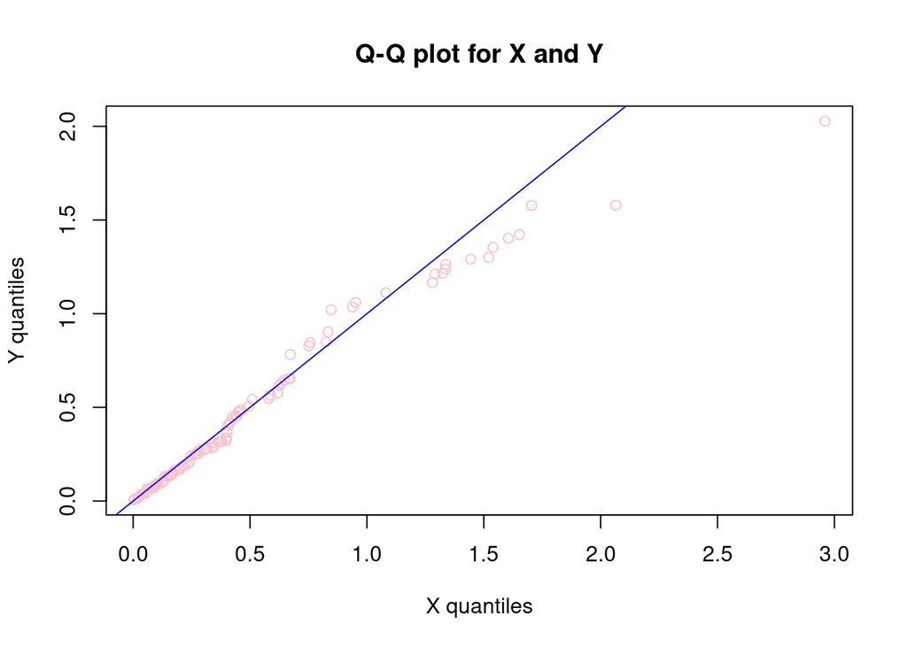

      ```r
      lambda <- 2
      n <- 100

      #generate a cdf for X and Y and set Z
      X <- rexp(n, rate = 2)
      Y <- rexp(n, rate = 2)
      Z = log(X) + 5  # Z is dependent on X

      # Q-Q plot for X and Y
      qqplot(X, Y, main = "Q-Q plot for X and Y",
          xlab = "X quantiles",
          ylab = "Y quantiles",
          col = "pink")
      abline(0, 1, col = "blue")
      ```

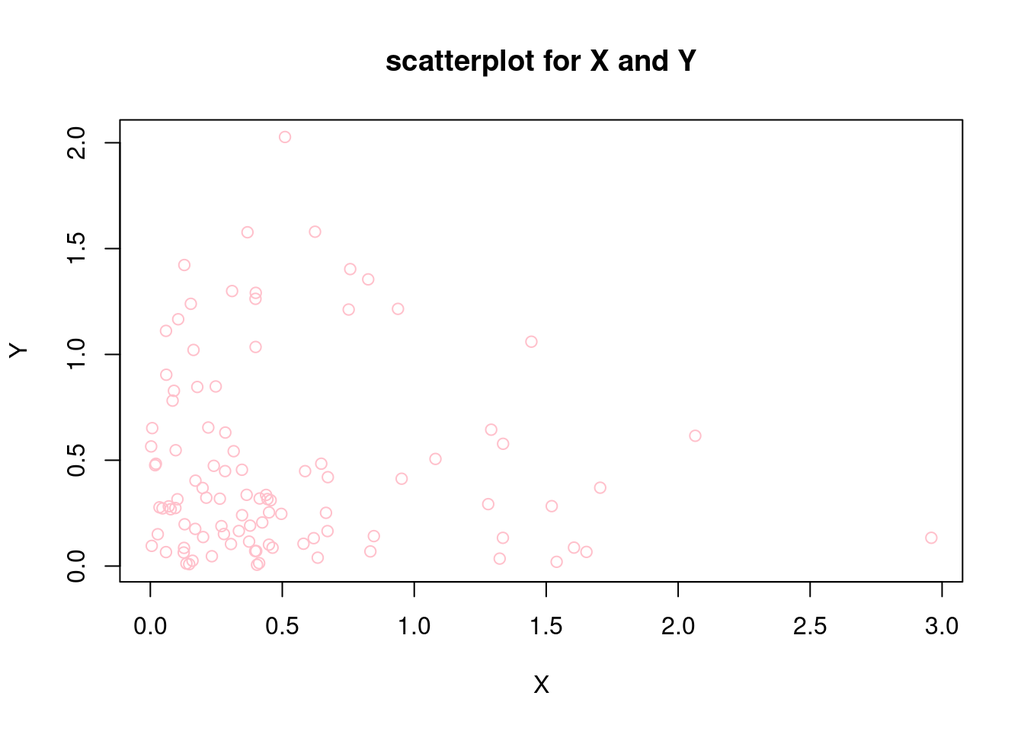

      ```r
      # scatterplot for X and Y
      plot(X, Y, main = "scatterplot for X and Y",
          xlab = "X",
          ylab = "Y",
          col = "pink")
      ```

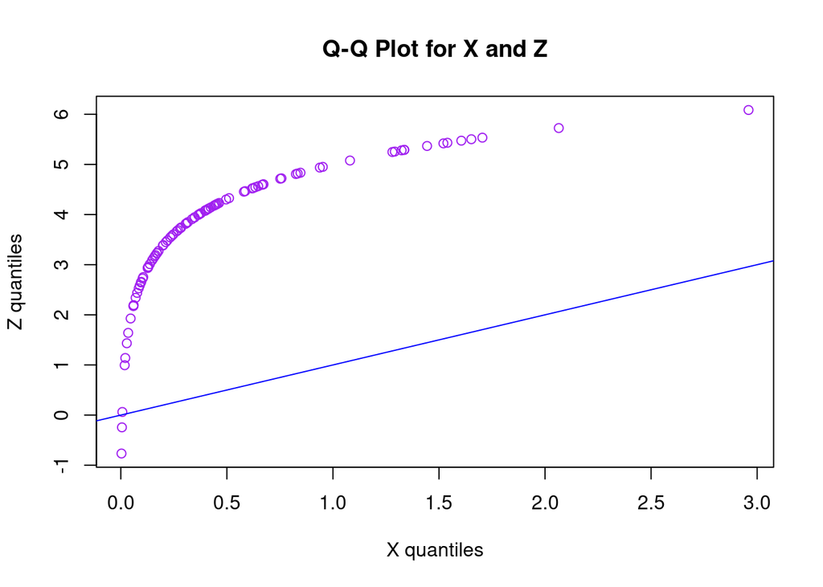

      ```r
      # Q-Q plot for X and Z
      qqplot(X, Z, main = "Q-Q Plot for X and Z",
          xlab = "X quantiles",
          ylab = "Z quantiles",
          col = "purple")
      abline(0, 1, col = "blue")
      ```